# MEDICAL INSURANCE DATA ANALYSIS PROJECT

### scatter plot of age and insurance

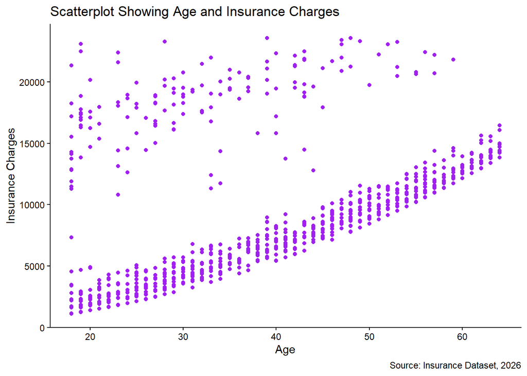

```r
h_cleaned_processed1 |>
  ggplot(aes(x = age, y = charges)) +
  geom_point(color = "purple") +
  labs(
    x = "Age",
    y = "Insurance Charges",
    title = "Scatterplot Showing Age and Insurance Charges",
    caption = "Source: Insurance Dataset, 2026"
  ) +
  theme_classic()
```

The scatterplot reveals a positive relationship between age and insurance charges — as age increases, charges tend to rise. Two distinct bands are visible: a lower band where charges increase gradually with age, and an upper band of consistently higher charges across all age groups, likely driven by high-risk individuals such as smokers. This pattern suggests that while age is a contributing factor, other characteristics significantly influence the level of charges.

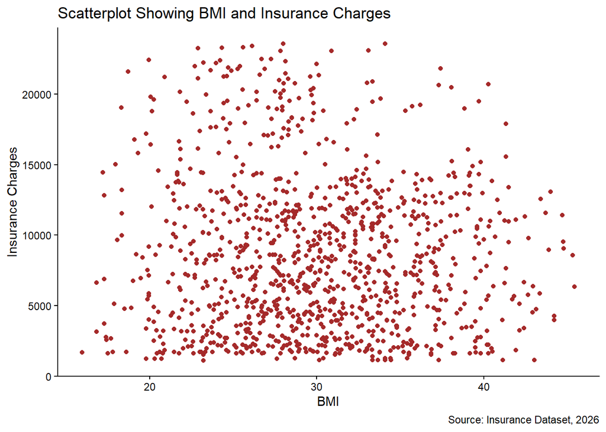

```r
h_cleaned_processed1 |>
  ggplot(aes(x = bmi, y = charges)) +
  geom_point(color = "brown") +
  labs(
    x = "BMI",
    y = "Insurance Charges",
    title = "Scatterplot Showing BMI and Insurance Charges",
    caption = "Source: Insurance Dataset, 2026"
  ) +
  theme_classic()
```

The scatterplot shows no clear linear relationship between BMI and insurance charges. Points are widely scattered across all BMI values, suggesting that BMI on its own is a weak predictor of charges.